# EDA

## 2. Simple plots

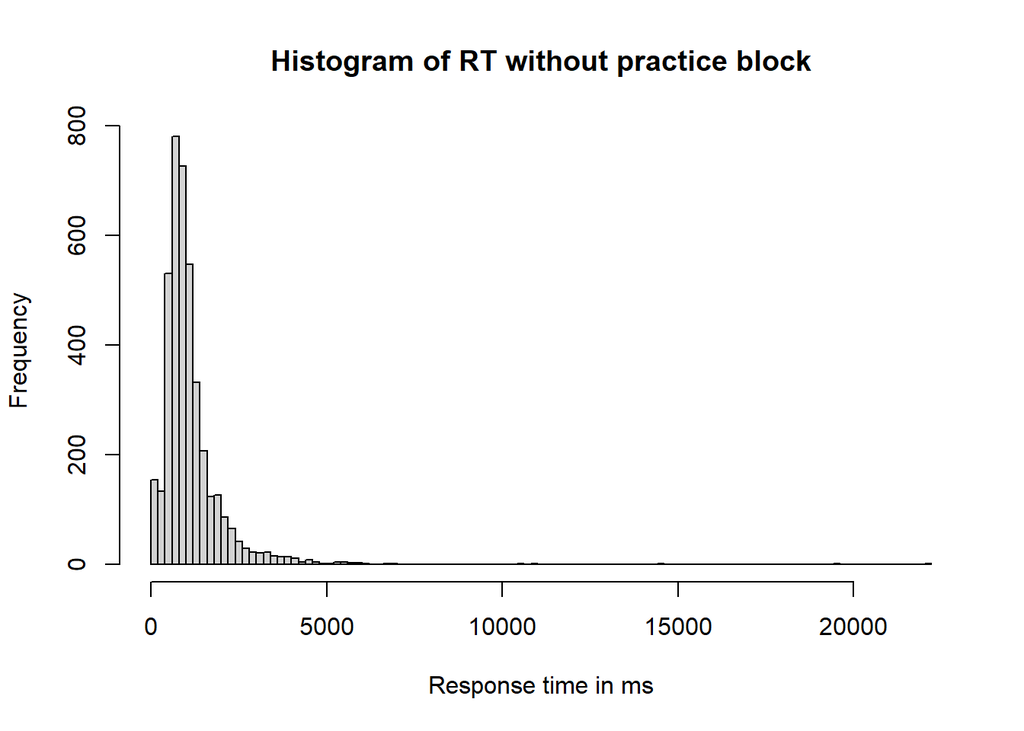

```r
hist(df_no_prc$duration, breaks=100,
     main="Histogram of RT without practice block",
     xlab="Response time in ms")
```

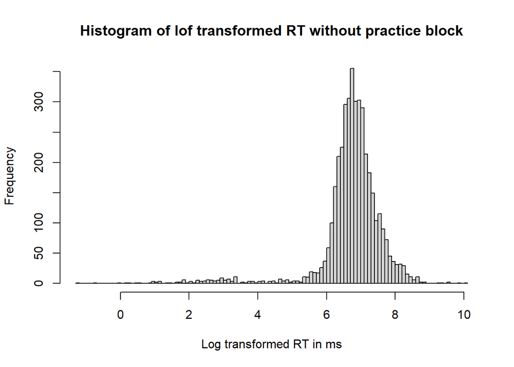

```r
hist(log(df_no_prc$duration), breaks=100,
     main="Histogram of lof transformed RT without practice block",
     xlab="Log transformed RT in ms")
```

Response time looks good. Original RT seems to be skewed (usual when using free response time paradigm). We can keep this, transform (log transform as below) or filter too delayed responses.

Lets going to have a look at maximed option. This variable could be interpreted as given correct response (or best response in this case).

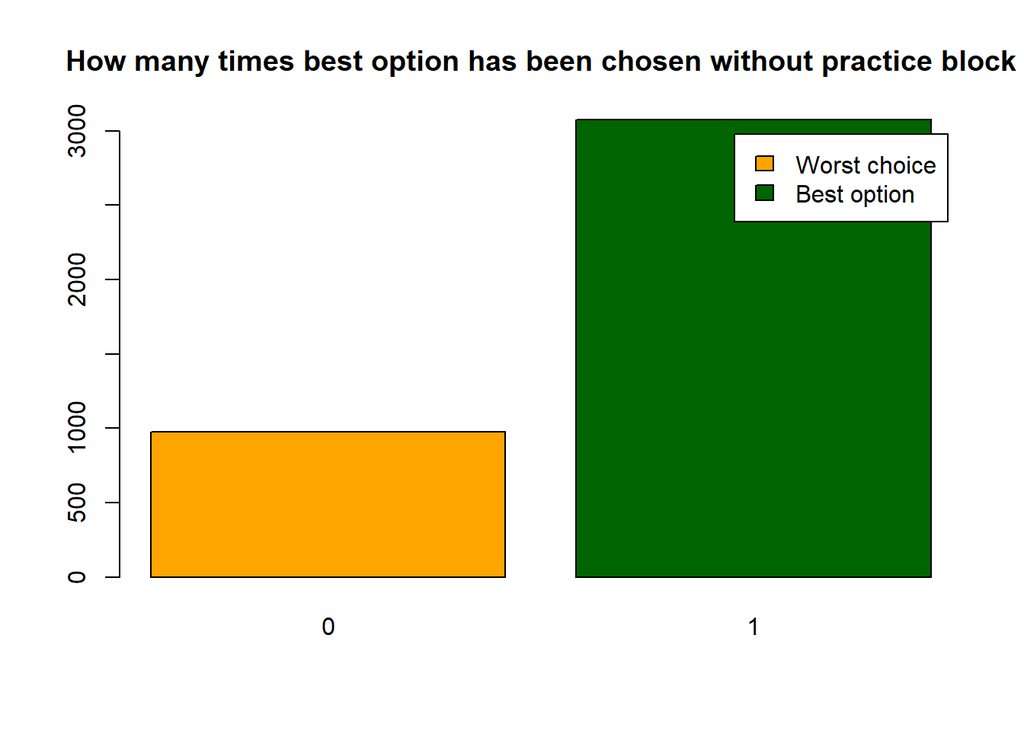

```r
barplot(table(df_no_prc$maximized_option),
        main="How many times best option has been chosen without practice block",
        legend.text = c("Worst choice", "Best option"),
        col = c("orange", "darkgreen"))
```

```r
print(paste0("Proportion of best option has been chosen is ",
             mean(df_no_prc$maximized_option),
             " and std is ",
             sd(df_no_prc$maximized_option)))
```

```
## [1] "Proportion of best option has been chosen is 0.759506172839506 and std is 0.427436144679684"
```

If we interpret chosing best option as performance, this indicates that our task is simple enough but we obtain a high standard deviation. Thus, lets have a look at each participant:

```r
# Looking how many times best options ha ben choosen, taking into account practice
df %>%
  group_by(subject_id) %>%
  summarize(N = n(),
            count = sum(maximized_option),
            mean = mean(maximized_option),
            std = sd(maximized_option))
```

```
## # A tibble: 15 × 5
##    subject_id     N count  mean   std
##    <fct>      <int> <int> <dbl> <dbl>
##  1 1            294   242 0.823 0.382
##  2 2            294   147 0.5   0.501
##  3 3            294    98 0.333 0.472
##  4 4            294   172 0.585 0.494
##  5 5            294   202 0.687 0.464
##  6 6            294   276 0.939 0.240
##  7 7            294   155 0.527 0.500
##  8 8            294   244 0.830 0.376
##  9 9            294   275 0.935 0.246
## 10 10           294   262 0.891 0.312
## 11 11           294   264 0.898 0.303
## 12 12           294   254 0.864 0.343
## 13 13           294   260 0.884 0.320
## 14 14           294   263 0.895 0.308
## 15 15           294   246 0.837 0.370
```

Some participants have extremely poor performance. This might be because we are looking also at practice. Lets look just main blocks (no practice):

```r
df_no_prc %>%
  group_by(subject_id) %>%
  summarize(N = n(),
            count = sum(maximized_option),
            mean = mean(maximized_option),
            std = sd(maximized_option))
```

```
## # A tibble: 15 × 5
##    subject_id     N count  mean   std
##    <fct>      <int> <int> <dbl> <dbl>
##  1 1            270   224 0.830 0.377
##  2 2            270   137 0.507 0.501
##  3 3            270    80 0.296 0.457
##  4 4            270   158 0.585 0.494
##  5 5            270   183 0.678 0.468
##  6 6            270   252 0.933 0.250
##  7 7            270   141 0.522 0.500
##  8 8            270   227 0.841 0.367
##  9 9            270   252 0.933 0.250
## 10 10           270   241 0.893 0.310
## 11 11           270   241 0.893 0.310
## 12 12           270   236 0.874 0.332
## 13 13           270   237 0.878 0.328
## 14 14           270   240 0.889 0.315
## 15 15           270   227 0.841 0.367
```

Some participants has really poor performance. Participant 3 must have misunderstood which was the color representing losses (even when we proportioned feedback at practice). Participants 2, 4 or 7 have a performance close to 0.5. this could be interpreted as random choices or problems detecting color proportions (visual problems? Should we warn about visual impairments?).

## 3. Comparison between domains

Lets make some initial comparisons between domains.

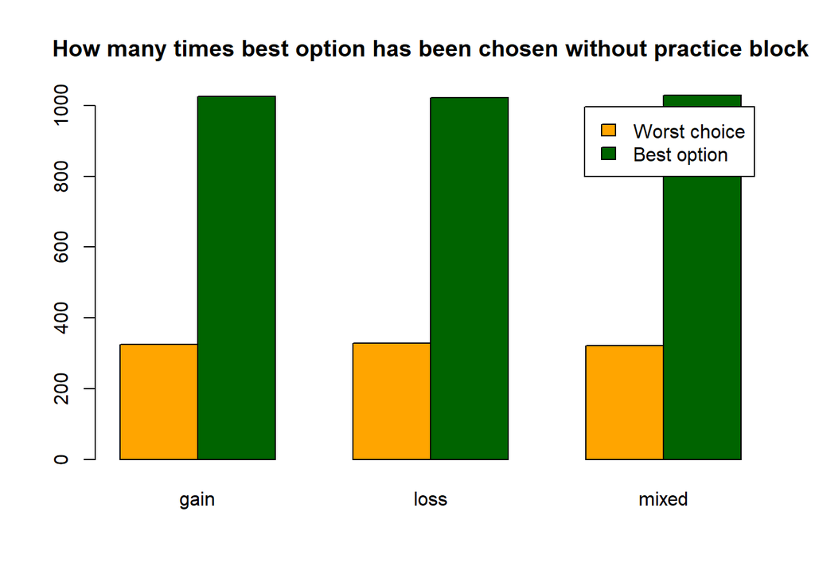

```r
barplot(table(df_no_prc$maximized_option, df_no_prc$domain),
        main="How many times best option has been chosen without practice block",
        legend.text = c("Worst choice", "Best option"),
        col = c("orange", "darkgreen"),
        beside=TRUE)
```

```r
df_no_prc %>%
  group_by(domain, maximized_option) %>%
  summarize(N = n())
```

```
## # A tibble: 6 × 3
## # Groups:   domain [3]
##   domain maximized_option     N
##   <fct>             <int> <int>
## 1 gain                  0   325
## 2 gain                  1  1025
## 3 loss                  0   328
## 4 loss                  1  1022
## 5 mixed                 0   321
## 6 mixed                 1  1029
```

No differences between domains in how many best options have chosen.

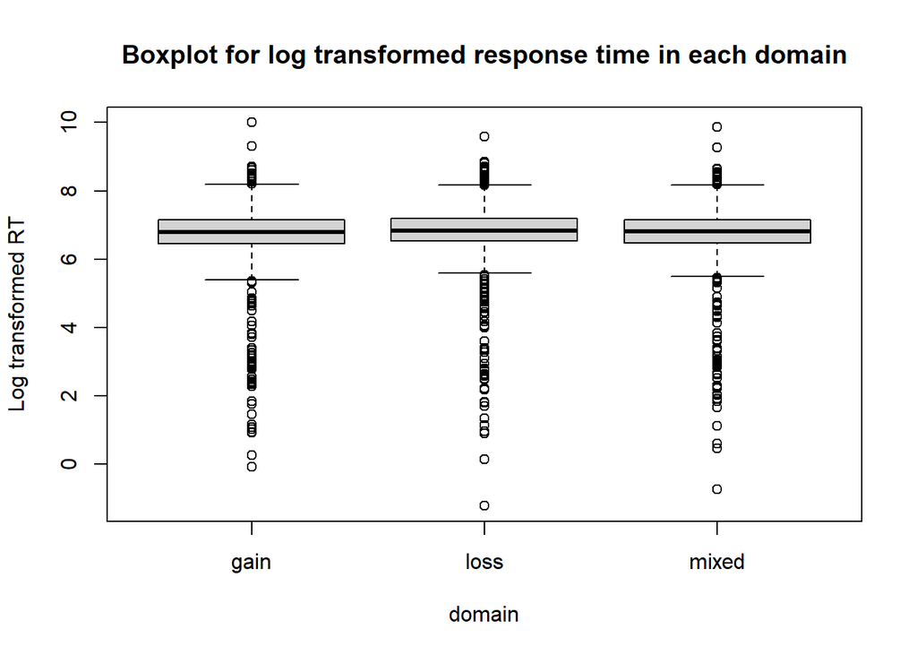

```r
boxplot(log(duration) ~ domain, data=df_no_prc,
        main="Boxplot for log transformed response time in each domain",
        ylab="Log transformed RT")
```

```r
df_no_prc %>%
  group_by(domain) %>%
  summarize(min = min(duration),
            Q1 = quantile(duration, 0.25),
            mean = mean(duration),
            median = median(duration),
            Q3 = quantile(duration, 0.75),
            max = max(duration))
```

```
## # A tibble: 3 × 7
##   domain   min    Q1  mean median    Q3    max
##   <fct>  <dbl> <dbl> <dbl>  <dbl> <dbl>  <dbl>
## 1 gain   0.914  629. 1088.   885. 1273. 22063.
## 2 loss   0.292  683. 1145.   929. 1320. 14509.
## 3 mixed  0.477  651. 1118.   905. 1285. 19457.
```

In response time we find more differences.

In any case, this is just piloting 15 participants. We must wait for a complete sample.

## Extra checks

One assumption someone could have is: more difference between image presented would make easier to chose best option.

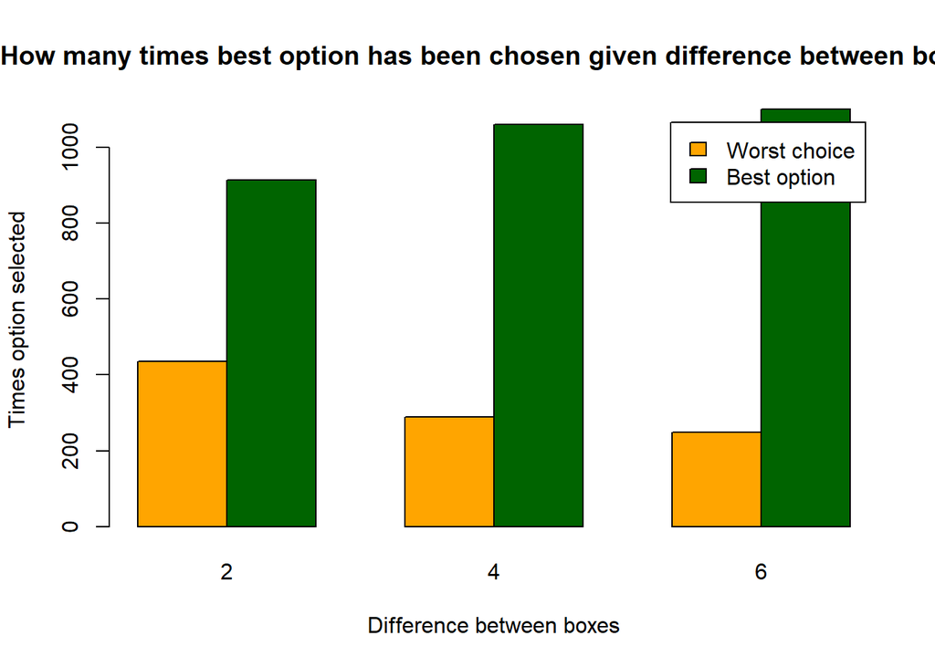

```r
barplot(table(df_no_prc$maximized_option, df_no_prc$diff_net_value),
        main="How many times best option has been chosen given difference between boxes",
        ylab="Times option selected",
        xlab="Difference between boxes",
        legend.text = c("Worst choice", "Best option"),
        col = c("orange", "darkgreen"),
        beside=TRUE)
```

```r
df_no_prc %>%
  group_by(diff_net_value) %>%
  summarize(N = n(),
            count_maximized_option = sum(maximized_option),
            mean = mean(maximized_option))
```

```
## # A tibble: 3 × 4
##   diff_net_value     N count_maximized_option  mean
##            <int> <int>                  <int> <dbl>
## 1              2  1350                    914 0.677
## 2              4  1350                   1061 0.786
## 3              6  1350                   1101 0.816
```

This seems to be accomplished.

Lets have a look at how participants perform across blocks. Plots will be from 5 participants each, for readability. First for performance:

```r
mean_data <- group_by(df, subject_id, block) %>%
             summarise(maximized_option = mean(maximized_option))
```

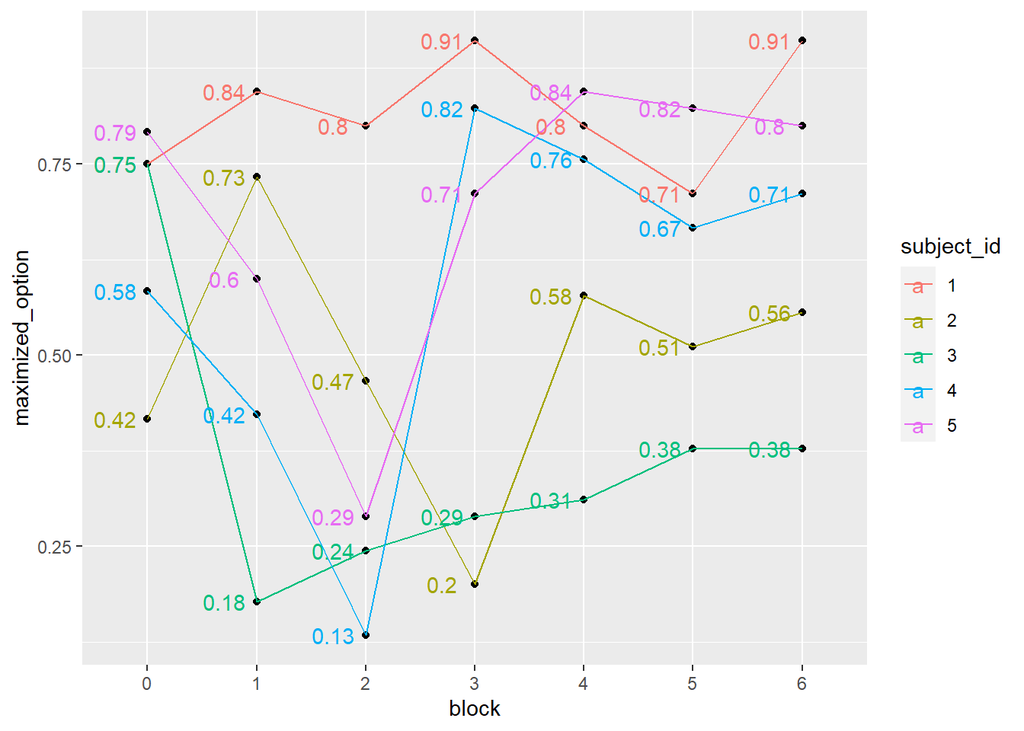

```r
library(ggplot2)
ggplot(mean_data[mean_data$subject_id %in% c(1,2,3,4,5),], aes(x = block, y = maximized_option, group = subject_id)) +
  geom_point() +
  geom_line(aes(color=subject_id)) +
  geom_text(aes(label = round(maximized_option, 2), color=subject_id), position = position_dodge(0.6, "single"))
```

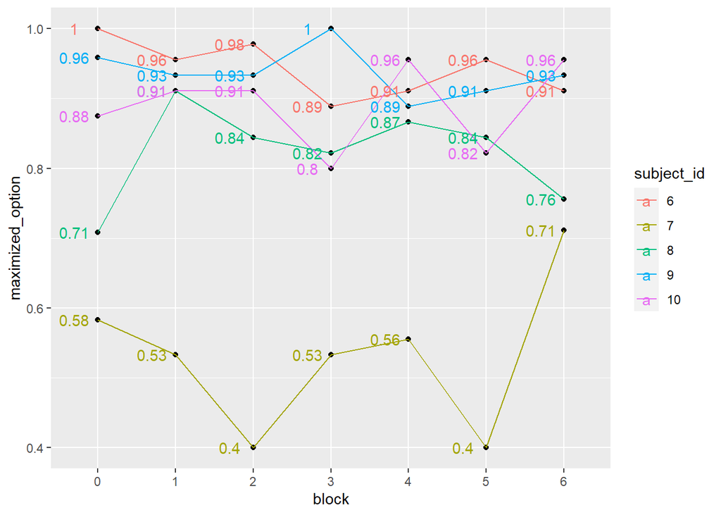

```r
ggplot(mean_data[mean_data$subject_id %in% c(6,7,8,9,10),], aes(x = block, y = maximized_option, group = subject_id)) +
  geom_point() +
  geom_line(aes(color=subject_id)) +
  geom_text(aes(label = round(maximized_option,2), color=subject_id), position = position_dodge(0.6, "single"))
```

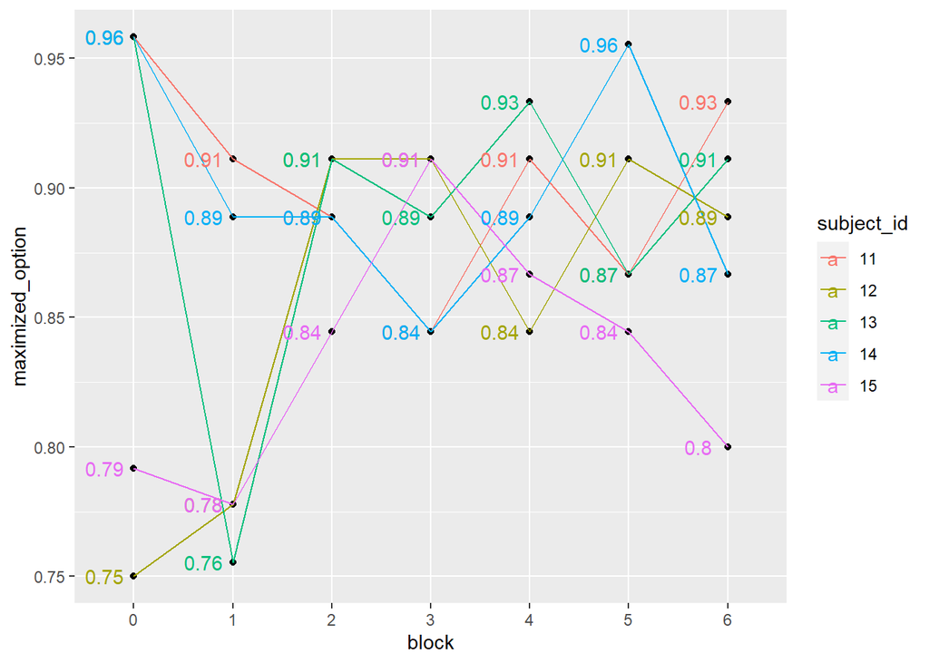

```r
ggplot(mean_data[mean_data$subject_id %in% c(11,12,13,14,15),], aes(x = block, y = maximized_option, group = subject_id)) +
  geom_point() +
  geom_line(aes(color=subject_id)) +
  geom_text(aes(label = round(maximized_option,2), color=subject_id), position = position_dodge(0.6, "single"))
```

And now for RT:

```r
mean_data <- group_by(df, subject_id, block) %>%
             summarise(duration = mean(duration))
```

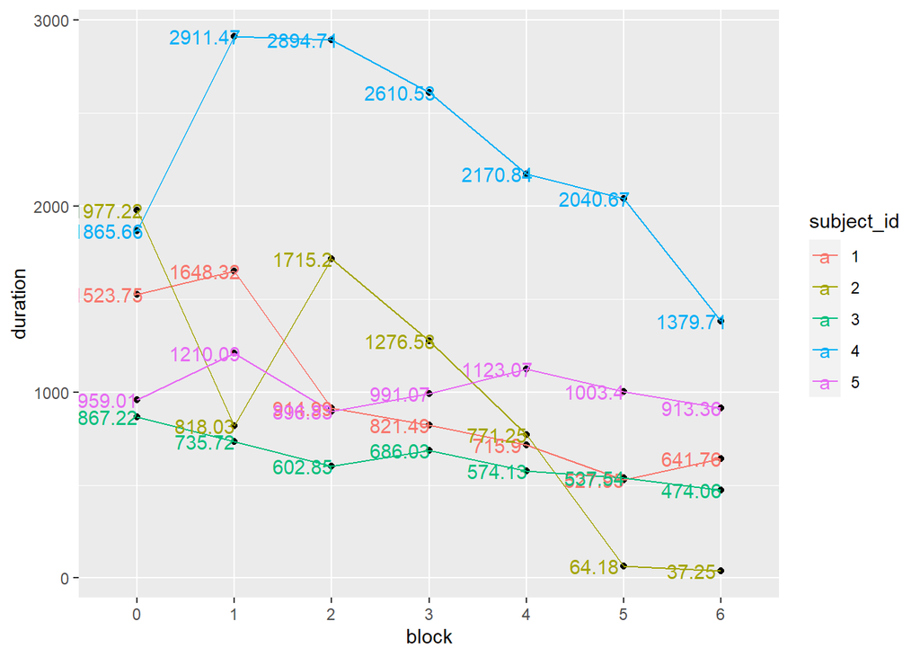

```r
library(ggplot2)
ggplot(mean_data[mean_data$subject_id %in% c(1,2,3,4,5),], aes(x = block, y = duration, group = subject_id)) +
  geom_point() +
  geom_line(aes(color=subject_id)) +
  geom_text(aes(label = round(duration, 2), color=subject_id), position = position_dodge(0.6, "single"))
```

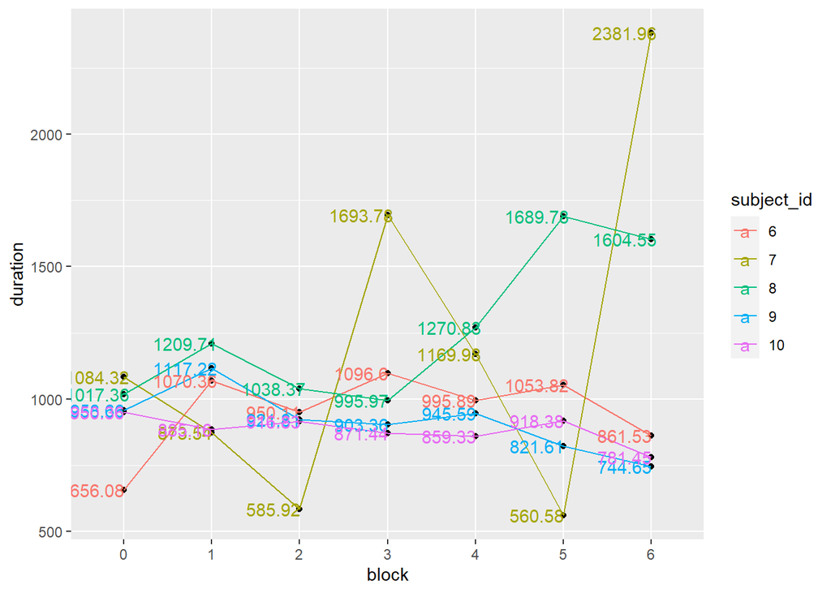

```r
ggplot(mean_data[mean_data$subject_id %in% c(6,7,8,9,10),], aes(x = block, y = duration, group = subject_id)) +
  geom_point() +
  geom_line(aes(color=subject_id)) +
  geom_text(aes(label = round(duration,2), color=subject_id), position = position_dodge(0.6, "single"))
```

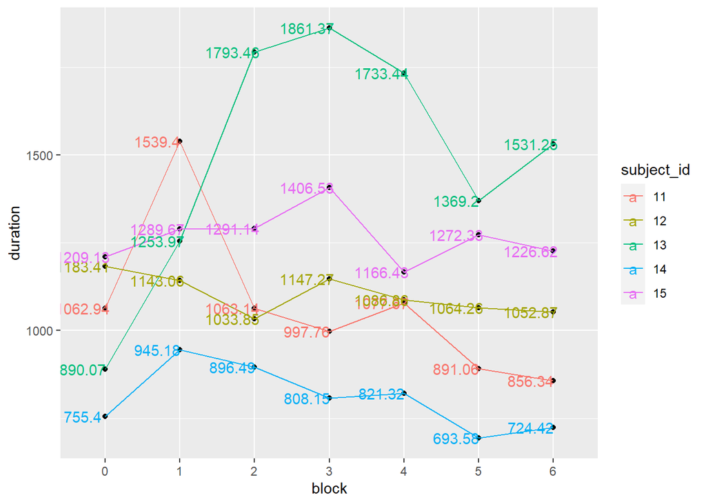

```r
ggplot(mean_data[mean_data$subject_id %in% c(11,12,13,14,15),], aes(x = block, y = duration, group = subject_id)) +
  geom_point() +
  geom_line(aes(color=subject_id)) +
  geom_text(aes(label = round(duration,2), color=subject_id), position = position_dodge(0.6, "single"))
```